# ARIMA

Giovani Valdrighi, Vitória Guardieiro

13/10/2020

## ARIMA Identification

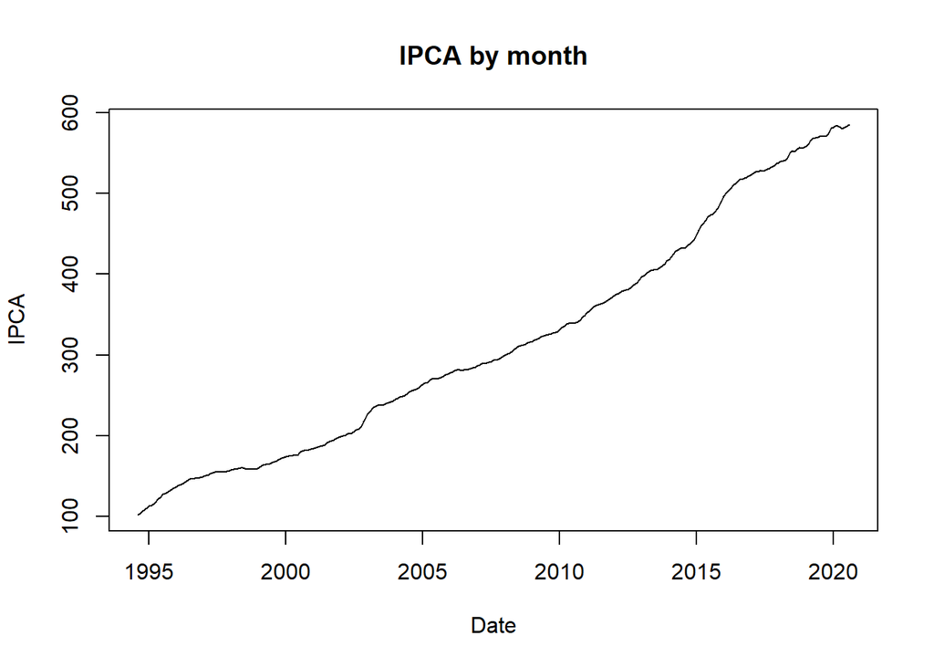

```r
ipca <- read.csv("ipca.csv")
ipca.ts <- ts(ipca$ipca.acum, start = c(1994, 8), frequency = 12)
plot(ipca.ts, type = "l", main = "IPCA by month", ylab = "IPCA", xlab = "Date")
```

Steps for the ARIMA model identification:

- Verify if the series need a transformation to estabilize the variance.
- Differentiate the series how many times it’s needed to the series ACF decay fast to 0. In this step it can also be used the Dickey Fuller test.
- Indentify the ARMA(p, q) process by the ACF and PACF plots.

We see that our data show a small variance, and it’s the same along the observed period. Now we differentiate the serie.

```r
diff_series <- function(data, d){
  if(d > 0){
    for(i in 1:d){
      data = diff(data)
    }
  }
  par(mfrow = c(1, 2))
  acf(data, main = "IPCA ACF")
  pacf(data, main = "IPCA PACF")
}
```

### Diff 0 times

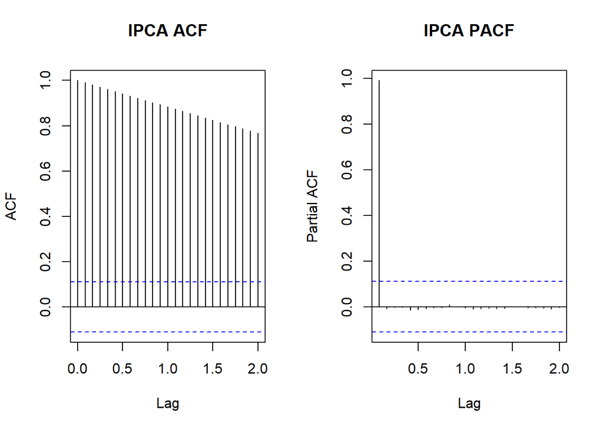

```r
diff_series(ipca.ts, 0)
```

### Diff 1 time

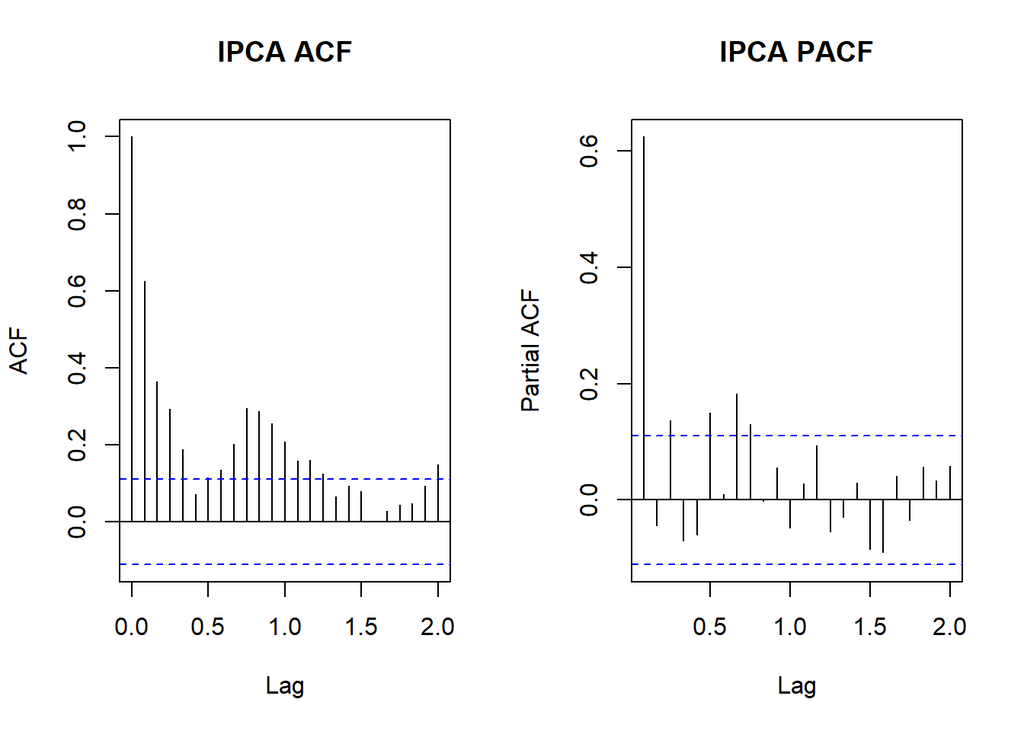

```r
diff_series(ipca.ts, 1)
```

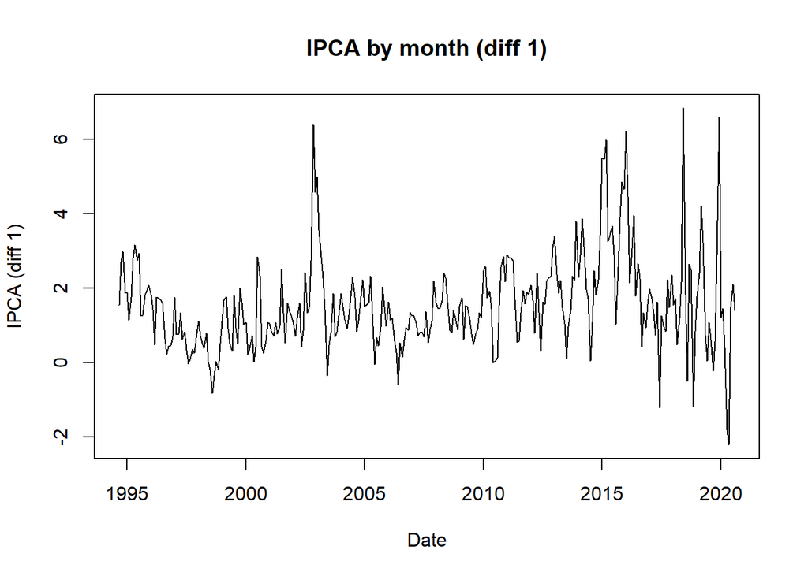

```r
plot((diff(ipca.ts)), main = "IPCA by month (diff 1)", xlab = "Date", ylab = "IPCA (diff 1)")
```

### Diff 2 times

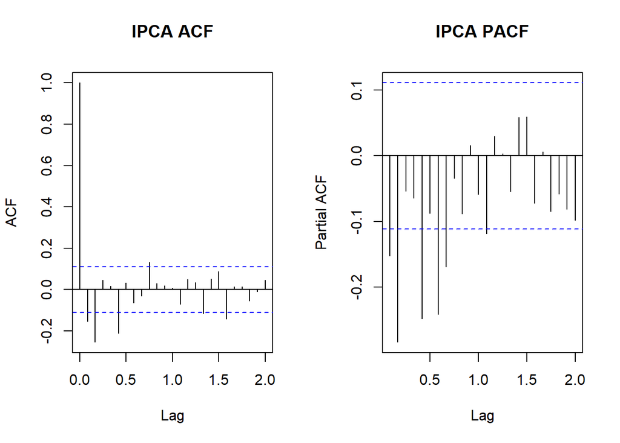

```r
diff_series(ipca.ts, 2)
```

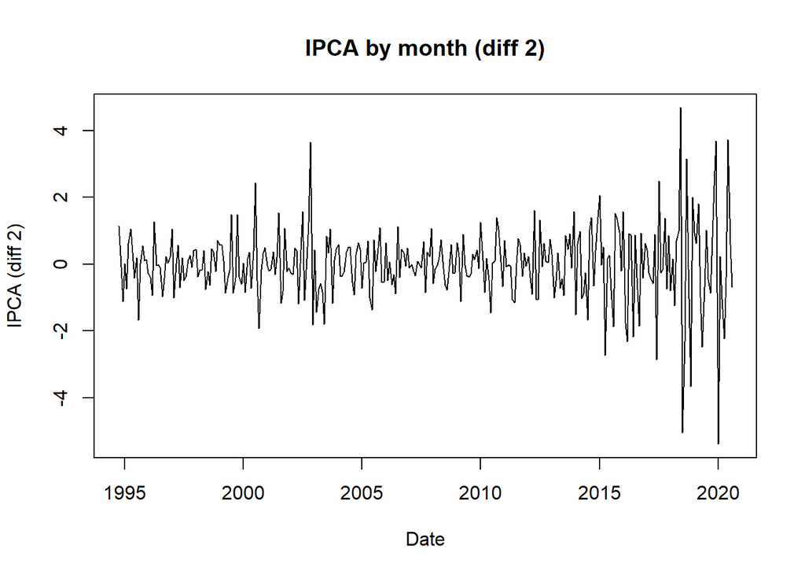

```r
plot(diff(diff(ipca.ts)), main = "IPCA by month (diff 2)", xlab = "Date", ylab = "IPCA (diff 2)")
```

With 2 differentiation the ACF decay fast, but the first lag is negative on the ACF, what is a indicator of over-differenced. So let’s apply the Dickey Fuller test on both models.

```r
diff1_ipca <- diff(ipca.ts, differences = 1)
diff2_ipca <- diff(ipca.ts, differences = 2)
adf.test(diff1_ipca)
```

```
##
##  Augmented Dickey-Fuller Test
##
## data:  diff1_ipca
## Dickey-Fuller = -5.1691, Lag order = 6, p-value = 0.01
## alternative hypothesis: stationary
```

```r
adf.test(diff2_ipca)
```

```
##
##  Augmented Dickey-Fuller Test
##
## data:  diff2_ipca
## Dickey-Fuller = -11.707, Lag order = 6, p-value = 0.01
## alternative hypothesis: stationary
```

Let’s keep only one differentiation.

### Identify ARMA(p, q)

Now let’s look at the IPCA to identify the ARMA(p, q) order.

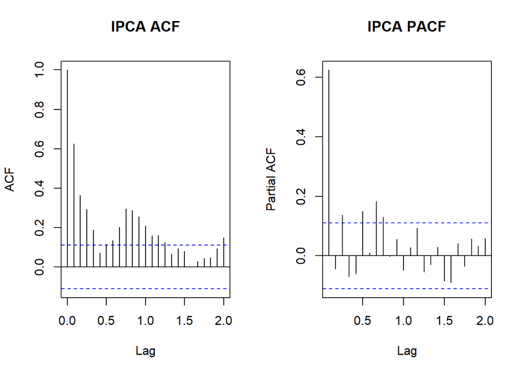

```r
diff_series(diff1_ipca, d = 0)
```

As the PACF decays fast, it appears to be a MA model, and the signicant values for the ACF are before the lag 4, so we start with testing the model MA(4).

```r
model.ma <- arma(diff1_ipca, order = c(0, 4))
summary(model.ma)
```

```
##
## Call:
## arma(x = diff1_ipca, order = c(0, 4))
##
## Model:
## ARMA(0,4)
##
## Residuals:
##      Min       1Q   Median       3Q      Max
## -3.43382 -0.54854 -0.08234  0.44505  4.74615
##
## Coefficient(s):
##            Estimate  Std. Error  t value Pr(>|t|)
## ma1         0.67154     0.05460   12.300  < 2e-16 ***
## ma2         0.31306     0.06204    5.046 4.52e-07 ***
## ma3         0.28393     0.06136    4.627 3.70e-06 ***
## ma4         0.30483     0.05892    5.174 2.29e-07 ***
## intercept   1.54295     0.13842   11.147  < 2e-16 ***
## ---
## Signif. codes:  0 '***' 0.001 '**' 0.01 '*' 0.05 '.' 0.1 ' ' 1
##
## Fit:
## sigma^2 estimated as 0.9216,  Conditional Sum-of-Squares = 282.95,  AIC = 869.96
```

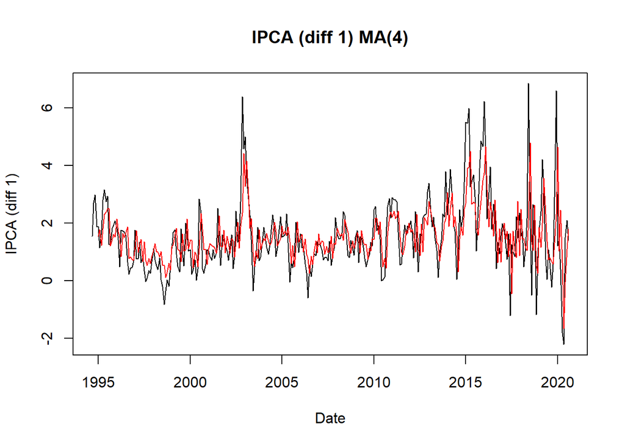

```r
plot(diff1_ipca, ylab = "IPCA (diff 1)", xlab = "Date", main = "IPCA (diff 1) MA(4)")
lines(model.ma$fitted.values, col = "red")
```

We can use the function *auto.arima* that try different models and choose the with the best AIC.

```r
model.auto <- auto.arima(diff1_ipca, ic = "aic")
summary(model.auto)
```

```
## Series: diff1_ipca
## ARIMA(0,1,3)
##
## Coefficients:
##           ma1      ma2      ma3
##       -0.3318  -0.4024  -0.1129
## s.e.   0.0568   0.0521   0.0498
##
## sigma^2 estimated as 0.9727:  log likelihood=-436.04
## AIC=880.07   AICc=880.2   BIC=895.03
##
## Training set error measures:
##                       ME      RMSE      MAE  MPE MAPE      MASE        ACF1
## Training set -0.01535242 0.9798978 0.673415 -Inf  Inf 0.6395201 0.002936075
```

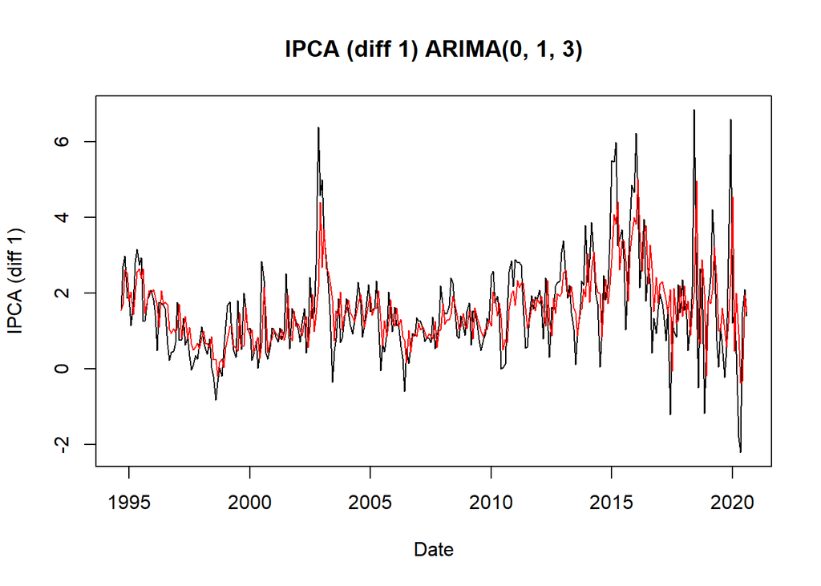

```r
plot(diff1_ipca, ylab = "IPCA (diff 1)", xlab = "Date", main = "IPCA (diff 1) ARIMA(0, 1, 3)")
lines(model.auto$fitted, col = "red")
```

We see that the auto ARIMA function fits an ARIMA(0, 1, 3), but the AIC is bigger than our MA(4).

### MA(4)

Let’s look at the residuals from our MA(4) model.

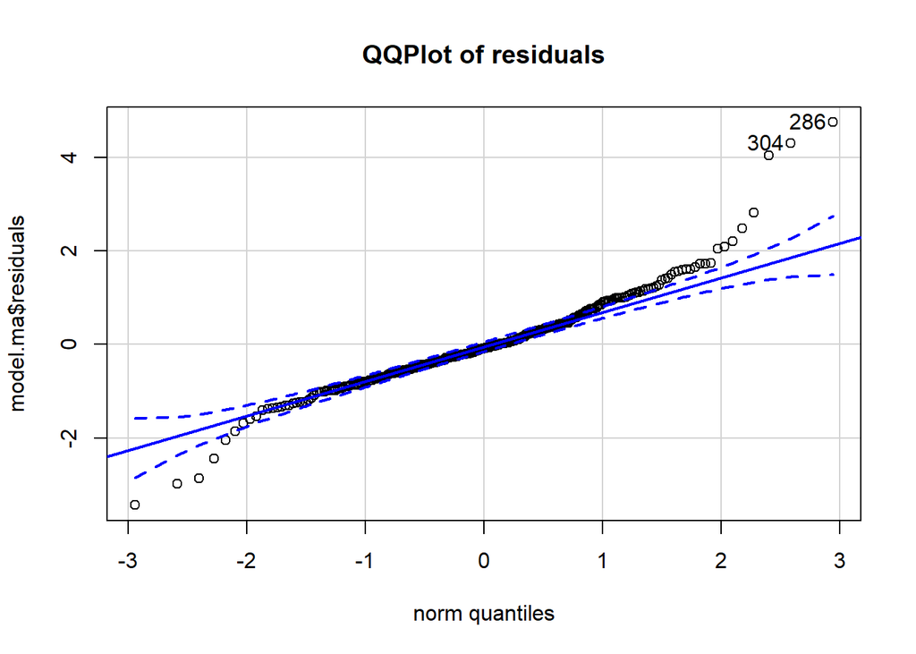

```
## [1] 286 304
```

```r
qqPlot(model.ma$residuals, main = "QQPlot of residuals")
```

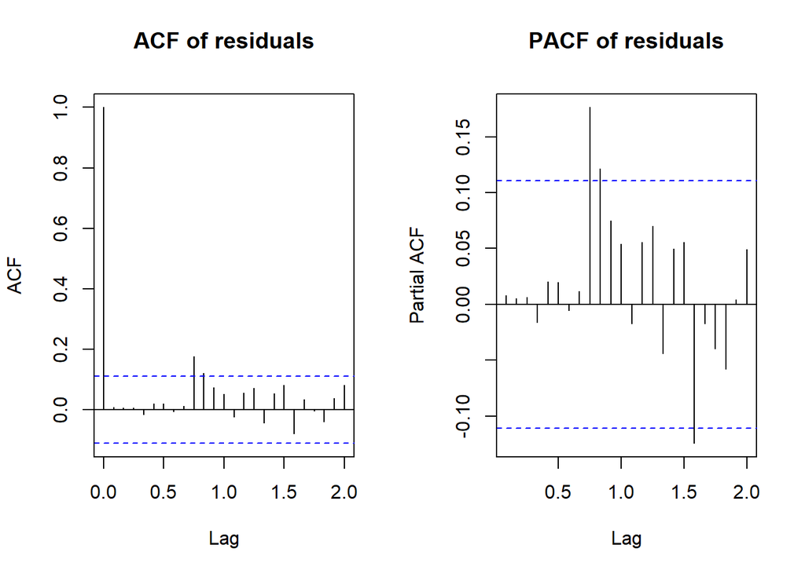

```r
par(mfrow = c(1, 2))
acf(model.ma$residuals, na.action = na.pass, main = "ACF of residuals")
pacf(model.ma$residuals, na.action = na.pass, main = "PACF of residuals")
```